# Assignment: Data Queries

Jonathon Doretti

2024-06-11 19:36:10

# Instructions

This assignment reviews the *Data Queries* content. You will use the **data_queries.Rmd** file I reviewed as part of the lectures for this week to complete this assignment. You will *copy and paste* relevant code from that file and update it to answer the questions in this assignment. You will respond to questions in each section after executing relevant code to answer a question. You will submit this assignment to its *Submissions* folder on *D2L*. You will submit *two* files:

1. this completed *R Markdown* script, and
2. an *HTML* rendered version of it to *D2L*.

To start:

First, create a folder on your computer to save all relevant files for this course. If you did not do so already, you will want to create a folder named **mgt_585** that contains all of the materials for this course.

Second, inside of **mgt_585**, you will create a folder to host assignments. You can name that folder **assignments**. Inside the **assignments** folder, you can create a folder for topic assignments named: **topics**.

Third, inside of the **topics** folder, you will create folders for each assignment. You can name the folder for this assignment: **01_data_queries**.

Fourth, create two additional folders in **01_data_queries** named **scripts**, **data**, and **plots**. Store this script in the **scripts** folder and the data for this assignment in the **data** folder.

Fifth, go to the *File* menu in *RStudio*, select *New Project…*, choose *Existing Directory*, go to your */mgt_585/assignments/topics/01_data_queries* folder to select it as the top-level directory for this *R Project*.

# Global Settings

The first code chunk sets the global settings for the remaining code chunks in the document. Do *not* change anything in this code chunk.

# Activate Packages

In this code chunk, we load the following packages:

1. [here](https://here.r-lib.org);
2. [tidyverse](https://www.tidyverse.org);
3. [readxl](https://readxl.tidyverse.org);
4. [lubridate](https://lubridate.tidyverse.org/index.html);
5. [skimr](https://docs.ropensci.org/skimr/);
6. [scales](https://scales.r-lib.org).

Make sure you installed these packages when you reviewed the analytical lecture.

We will use functions from these packages to examine the data. Do *not* change anything in this code chunk.

```r
## here for project workflow
library(here)

## tidyverse for data manipulation and plotting;
## loads eight different packages simultaneously
library(tidyverse)

## readxl for Excel files
library(readxl)

## lubridate for dates
library(lubridate)

## skimr for data summaries
library(skimr)

## scales for variable scales
library(scales)
```

# Task 1: Import Data

We will use the same data as in the analytical lecture: **clients.xlsx**. After you load the data, then you will execute other commands on the data.

## Task 1.1

Use the **read_excel()** and **here()** functions to load the *second sheet* from this Excel data file for this working session. Save the data as the object **clients_raw**.

After you load the data, look at your *Global Environment* window.

**Question 1.1**: Answer these questions: (1) How many *observations* are there in the data? (2) How many *variables* are there in the data?

**Response 1.1**: (1) 919 (2) 10

```r
clients_raw <- read_excel(
  ## use here() to locate file in our project directory
  here(
    # folder
    "data",
    # file
    "clients.xlsx"
  ),
  ## specify sheet
  sheet = 2
)
```

# Task 2: Clean Data

You will now inspect and clean the data.

## Task 2.1

Use the **glimpse()** function to view a preview of values for each variable in the data.

**Question 2.1**: Answer these questions: (1) What is the *first* value of the **age** variable? (2) How many variables are treated as character (i.e., **chr**) variables after importing the data?

**Response 2.1**: (1) 36 (2) 5

```r
glimpse(clients_raw)
```

```
## Rows: 919
## Columns: 10
## $ month         <dbl> 7, 7, 7, 7, 7, 7, 7, 7, 7, 7, 7, 7, 7, 7, 7, 7, 7, 7, 7,…
## $ credit_amount <dbl> 20500, 57500, 106000, 28000, 30000, 8500, 31500, 29500, …
## $ credit.term   <dbl> 24, 18, 15, 12, 12, 7, 12, 12, 10, 12, 12, 12, 12, 3, 10…
## $ age           <dbl> 36, 38, 32, 23, 22, 22, 27, 64, 43, 68, 64, 27, 72, 43, …
## $ sex           <chr> "male", "male", "female", "female", "female", "female", …
## $ education     <chr> "Higher education", "Secondary education", "Higher educa…
## $ product_type  <chr> "Computers", "Furniture", "Tourism", "Cell phones", "Com…
## $ region        <chr> "West", "West", "West", "West", "West", "West", "East", …
## $ income        <dbl> 31000, 36000, 49000, 31000, 46000, 18000, 61000, 12000, …
## $ FamilyStatus  <chr> "Unmarried", "Unmarried", "Unmarried", "Unmarried", "Mar…
```

## Task 2.2

Perform the following in one chained command. First, bind the name **clients_work** to an updated version of **clients_raw**. Second, update **clients_raw** by piping it to the **rename()** function to rename the following variables:

1. **credit.term** to **credit_term**;
2. **FamilyStatus** to **family_status**.

Third, pipe the result to **mutate()** to perform the following updates:

1. update the **month** column using the **month()** function to add abbreviated labels for each month;
2. apply the **across()** function to convert **c(sex, product_type:family_status, -income)** to *nominal* factors;
3. update **education** to be an *ordinal* factor with the following order: **“Incomplete secondary education”**, **“Secondary education”**, **“Secondary special education”**, **“Incomplete higher education”**, **“Higher education”**, and **“PhD degree”**.

Apply **glimpse()** to **clients_work** to preview the working data.

**Question 2.2**: Answer these questions: (1) How many *nominal* factor variables (indicated by *fct*) are there now in the data? (2) How many *ordinal* factor variables (indicated by *ord*) are there now in the data?

**Response 2.2**: (1) 4 (2) 2

```r
clients_work <- clients_raw %>%
  ## rename variables
  rename(
    # credit amount
    credit_term = credit.term,
    # product type
    family_status = FamilyStatus
  ) %>%
  ## mutate to factors
  mutate(
    ## convert to date
    month = month(
      # variable
      month,
      # labels
      label = TRUE
    ),
    ## apply function to columns
    across(
      # variables
      .cols = c(sex, product_type:family_status, -income),
      # convert to factors
      .fns = as_factor
    ),
    ## convert to factor
    education = factor(
      # column
      education,
      # levels
      levels = c(
        # lowest to highest
        "Incomplete secondary education",
        "Secondary education",
        "Secondary special education",
        "Incomplete higher education",
        "Higher education",
        "PhD degree"
      ),
      # ordered
      ordered = TRUE
    )
  )

glimpse(clients_work)
```

```
## Rows: 919
## Columns: 10
## $ month         <ord> Jul, Jul, Jul, Jul, Jul, Jul, Jul, Jul, Jul, Jul, Jul, J…
## $ credit_amount <dbl> 20500, 57500, 106000, 28000, 30000, 8500, 31500, 29500, …
## $ credit_term   <dbl> 24, 18, 15, 12, 12, 7, 12, 12, 10, 12, 12, 12, 12, 3, 10…
## $ age           <dbl> 36, 38, 32, 23, 22, 22, 27, 64, 43, 68, 64, 27, 72, 43, …
## $ sex           <fct> male, male, female, female, female, female, female, male…
## $ education     <ord> Higher education, Secondary education, Higher education,…
## $ product_type  <fct> Computers, Furniture, Tourism, Cell phones, Computers, H…
## $ region        <fct> West, West, West, West, West, West, East, West, West, We…
## $ income        <dbl> 31000, 36000, 49000, 31000, 46000, 18000, 61000, 12000, …
## $ family_status <fct> Unmarried, Unmarried, Unmarried, Unmarried, Married, Unm…
```

## Task 2.3

Update **clients_work** by overwriting it. First, pipe **clients_work** to **mutate()**. Use the combination of **across()**, **fct_relabel()**, and **str_to_title()** to change the casing of **c(sex:product_type)**. Second, pipe the result to **rowid_to_column()** to add an identifier column.

Print **clients_work**.

**Question 2.3**: Answer these questions: (1) What is the *credit amount* of the *fourth* client? (2) What is the *credit term* of the *third* client?

**Response 2.3**: (1) 28,000 (2) 15

```r
clients_work <- clients_work %>%
  ## mutate factor levels
  mutate(
    ## apply function to columns
    across(
      # variables
      .cols = c(sex:product_type),
      # convert to factors
      .fns = ~ fct_relabel(
        # factors
        .x,
        # relabeling function
        str_to_title
      )
    )
  ) %>%
  ## add row id
  rowid_to_column(
    # name
    var = "row_id"
  )

## print table
clients_work
```

| row_id | month | credit_amount | credit_term | age | sex | education | product_type | region | income | family_status |
| --- | --- | --- | --- | --- | --- | --- | --- | --- | --- | --- |
| 1 | Jul | 20500 | 24 | 36 | Male | Higher Education | Computers | West | 31000 | Unmarried |
| 2 | Jul | 57500 | 18 | 38 | Male | Secondary Education | Furniture | West | 36000 | Unmarried |
| 3 | Jul | 106000 | 15 | 32 | Female | Higher Education | Tourism | West | 49000 | Unmarried |
| 4 | Jul | 28000 | 12 | 23 | Female | Secondary Education | Cell Phones | West | 31000 | Unmarried |
| 5 | Jul | 30000 | 12 | 22 | Female | Higher Education | Computers | West | 46000 | Married |
| 6 | Jul | 8500 | 7 | 22 | Female | Higher Education | Household Appliances | West | 18000 | Unmarried |
| 7 | Jul | 31500 | 12 | 27 | Female | Higher Education | Cell Phones | East | 61000 | Unmarried |
| 8 | Jul | 29500 | 12 | 64 | Male | Secondary Special Education | Furniture | West | 12000 | Unmarried |
| 9 | Jul | 10000 | 10 | 43 | Female | Secondary Special Education | Household Appliances | West | 16000 | Married |
| 10 | Jul | 26000 | 12 | 68 | Male | Secondary Special Education | Medical Services | West | 19000 | Unmarried |

[output cut: 909 more lines]

# Task 3: Query Data

You will now query the data.

## Task 3.1

Perform the following two slices. First, pipe **clients_work** to **slice_max()** to slice for the *seven* maximum **credit_amount** values. Second, pipe **clients_work** to **slice_min()** to slice for the minimum *0.02* **credit_term** values with *no* ties.

**Question 3.1**: Answer these questions: (1) What is the maximum *credit amount* in the data? (2) What is the minimum *credit term* in the data?

**Response 3.1**: (1) 301000  
(2) 3

```r
### select particular rows by condition
## call data
clients_work %>%
  ## slice for maximum value
  slice_max(
    # variable
    credit_amount,
    # number
    n = 7
  )
```

| row_id | month | credit_amount | credit_term | age | sex | education | product_type | region | income | family_status |
| --- | --- | --- | --- | --- | --- | --- | --- | --- | --- | --- |
| 531 | Oct | 301000 | 36 | 32 | Male | Higher Education | Construction Materials | West | 121000 | Unmarried |
| 876 | Dec | 292500 | 6 | 34 | Male | Higher Education | Furniture | East | 241000 | Unmarried |
| 156 | Aug | 201000 | 24 | 26 | Female | Secondary Special Education | Windows & Doors | West | 41000 | Unmarried |
| 870 | Dec | 191000 | 12 | 39 | Male | Secondary Special Education | Clothing | West | 61000 | Unmarried |
| 425 | Oct | 186500 | 36 | 65 | Male | Secondary Special Education | Furniture | West | 21000 | Unmarried |
| 721 | Nov | 176000 | 36 | 31 | Male | Secondary Education | Clothing | West | 51000 | Unmarried |
| 639 | Nov | 157000 | 36 | 24 | Female | Higher Education | Boats | West | 39000 | Unmarried |

```r
### select particular rows by condition
## call data
clients_work %>%
  ## slice for minimum value
  slice_min(
    # variable
    credit_term,
    # proportion
    prop = 0.02,
    # ties
    with_ties = FALSE
  )
```

| row_id | month | credit_amount | credit_term | age | sex | education | product_type | region | income | family_status |
| --- | --- | --- | --- | --- | --- | --- | --- | --- | --- | --- |
| 14 | Jul | 41500 | 3 | 43 | Male | Higher Education | Clothing | West | 44000 | Unmarried |
| 25 | Jul | 21000 | 3 | 38 | Male | Secondary Special Education | Household Appliances | West | 101000 | Married |
| 31 | Jul | 12000 | 3 | 29 | Female | Secondary Special Education | Cell Phones | West | 36000 | Unmarried |
| 52 | Jul | 19000 | 3 | 72 | Male | Secondary Special Education | Furniture | West | 36000 | Unmarried |
| 56 | Jul | 29500 | 3 | 40 | Male | Higher Education | Furniture | East | 74000 | Married |
| 61 | Jul | 11000 | 3 | 58 | Male | Secondary Special Education | Furniture | West | 26000 | Married |
| 69 | Jul | 9000 | 3 | 33 | Male | Secondary Education | Household Appliances | West | 38000 | Unmarried |
| 83 | Jul | 52500 | 3 | 30 | Female | Secondary Education | Auto | West | 56000 | Married |
| 105 | Jul | 7500 | 3 | 31 | Female | Secondary Special Education | Furniture | West | 20000 | Unmarried |
| 121 | Jul | 24000 | 3 | 21 | Female | Secondary Special Education | Computers | East | 71000 | Unmarried |

[output cut: 8 more lines]

## Task 3.2

Arrange the rows of **clients_work** by *descending* **income** and *ascending* **age**.

**Question 3.2**: Answer these questions: (1) What is the highest *income* in the data? (2) What is the **row_id** of the third listed client?

**Response 3.2**: (1) 401000 (2) 897

```r
### arrange rows by variables
## call data
clients_work %>%
  ## arrange rows by column
  arrange(
    # descending
    desc(income),
    # ascending
    age,

  )
```

| row_id | month | credit_amount | credit_term | age | sex | education | product_type | region | income | family_status |
| --- | --- | --- | --- | --- | --- | --- | --- | --- | --- | --- |
| 380 | Sep | 6000 | 3 | 29 | Female | Higher Education | Household Appliances | West | 401000 | Unmarried |
| 876 | Dec | 292500 | 6 | 34 | Male | Higher Education | Furniture | East | 241000 | Unmarried |
| 897 | Dec | 93000 | 3 | 31 | Male | Higher Education | Clothing | West | 151000 | Unmarried |
| 467 | Oct | 21500 | 4 | 39 | Female | Higher Education | Computers | West | 151000 | Unmarried |
| 585 | Nov | 35000 | 10 | 31 | Male | Higher Education | Cell Phones | East | 121000 | Unmarried |
| 531 | Oct | 301000 | 36 | 32 | Male | Higher Education | Construction Materials | West | 121000 | Unmarried |
| 318 | Sep | 66500 | 24 | 38 | Male | Higher Education | Household Appliances | West | 121000 | Unmarried |
| 285 | Aug | 118500 | 11 | 37 | Female | Incomplete Secondary Education | Furniture | Midwest | 111000 | Unmarried |
| 748 | Nov | 21000 | 6 | 25 | Female | Secondary Special Education | Furniture | West | 101000 | Unmarried |
| 822 | Dec | 52500 | 6 | 26 | Male | Higher Education | Computers | East | 101000 | Unmarried |

[output cut: 909 more lines]

## Task 3.3

Perform the following query. First, pipe **clients_work** to **select()**. Select the following variables: **row_id**, **month**, **product_type**, and **income**.

Second, pipe the result to **filter()**. Filter for the following conditions:

1. filter for *November* and *December* with **month %in% c(“Nov”, “Dec”)**;
2. **income** less than `$50,000`.

**Question 3.3**: How many clients meet these conditions?

**Response 3.3**: 286

```r
clients_work %>%
  ## select variables
  select(row_id, month, product_type, income) %>%
  ## filter rows
  filter(
    # exclude products
    month %in% c("Nov", "Dec"),
    # credit amount limit
    income < 50000
  )
```

| row_id | month | product_type | income |
| --- | --- | --- | --- |
| 586 | Nov | Cell Phones | 36000 |
| 587 | Nov | Computers | 46000 |
| 588 | Nov | Computers | 21000 |
| 589 | Nov | Auto | 39000 |
| 590 | Nov | Cell Phones | 27000 |
| 591 | Nov | Furniture | 41000 |
| 592 | Nov | Cosmetics And Beauty Services | 24000 |
| 593 | Nov | Computers | 21000 |
| 595 | Nov | Cell Phones | 21000 |
| 596 | Nov | Computers | 21000 |

[output cut: 276 more lines]

# Task 4: Summarize Variables

You will now compute summaries of the data.

## Task 4.1

Perform the following summary computations. First, pipe **clients_work** to **count()**. Count by **region** and **family_status**. Second, pipe the result to **group_by()**. Group by **region**. Third, pipe the result to **mutate()**. Calculate **prop** as **n / sum(n)**.

**Question 4.1**: Irrespective of *region*, what is the *most* frequent *family status* category?

**Response 4.1**: The most frequent family status category irrespective of region is Unmarried.

```r
### count values by groups
## call data
clients_work %>%
  ## count by multiple variables
  count(region, family_status) %>%
  ## groups
  group_by(region) %>%
  ## update
  mutate(
    # proportions
    prop = n / sum(n)
  )
```

| region | family_status | n | prop |
| --- | --- | --- | --- |
| West | Unmarried | 525 | 0.69536424 |
| West | Married | 197 | 0.26092715 |
| West | DSW | 33 | 0.04370861 |
| East | Unmarried | 91 | 0.72222222 |
| East | Married | 29 | 0.23015873 |
| East | DSW | 6 | 0.04761905 |
| Midwest | Unmarried | 26 | 0.68421053 |
| Midwest | Married | 10 | 0.26315789 |
| Midwest | DSW | 2 | 0.05263158 |

## Task 4.2

Perform the following summary computations. First, pipe **clients_work** to **group_by()**. Group by **sex**. Second, pipe the result to **select()**. Select **credit_term**, **region**, and **income**. Third, pipe the result to **skim()**.

**Question 4.2**: Answer these questions: (1) What is the *75th percentile* of *income* for *men*? (2) How many *women* are in the *West* region?

**Response 4.2**: (1) 36000 (2) 354

```r
### summarize data by group
## call data
clients_work %>%
  ## group by variable
  group_by(sex) %>%
  ## select variables
  select(credit_term, region, income) %>%
  ## summarize
  skim()
```

Data summary

| Name | Piped data |
| --- | --- |
| Number of rows | 919 |
| Number of columns | 4 |
| _______________________ |  |
| Column type frequency: |  |
| factor | 1 |
| numeric | 2 |
| ________________________ |  |
| Group variables | sex |

**Variable type: factor**

| skim_variable | sex | n_missing | complete_rate | ordered | n_unique | top_counts |
| --- | --- | --- | --- | --- | --- | --- |
| region | Male | 0 | 1 | FALSE | 3 | Wes: 401, Eas: 73, Mid: 18 |
| region | Female | 0 | 1 | FALSE | 3 | Wes: 354, Eas: 53, Mid: 20 |

**Variable type: numeric**

| skim_variable | sex | n_missing | complete_rate | mean | sd | p0 | p25 | p50 | p75 | p100 | hist |
| --- | --- | --- | --- | --- | --- | --- | --- | --- | --- | --- | --- |
| credit_term | Male | 0 | 1 | 11.93 | 7.34 | 3 | 6 | 12 | 12 | 36 | ▆▇▁▁▁ |
| credit_term | Female | 0 | 1 | 11.41 | 6.50 | 3 | 6 | 12 | 12 | 36 | ▆▇▁▁▁ |
| income | Male | 0 | 1 | 31172.76 | 20185.81 | 6000 | 19000 | 26000 | 36000 | 241000 | ▇▁▁▁▁ |
| income | Female | 0 | 1 | 36217.80 | 24997.97 | 1000 | 26000 | 31000 | 41000 | 401000 | ▇▁▁▁▁ |

# Task 5: Data Visualization

You will now visualize the data.

## Task 5.1

Create a horizontal bar plot of **product_type** that calculates the percentages of clients in each category. First, bind the name **product_type_plot** to a **ggplot()** object. Second, inside of **ggplot()** specify **clients_work** as the *data* input; map **product_type** to the *y-axis* using **fct_infreq()** and **fct_rev()** around it; map **group** to **1**. Third, add a **geom_bar()** layer; map **prop** to the *x-axis* using **after_stat()**; set **fill** to **lightblue**. Fourth, add a **geom_text()** layer; set **stat** to **“count”**; map **prop** to the *x-axis* using **after_stat()**; map **prop** to the **label** using **after_stat()** and **percent()**; set **color** to **black**; set **size** to **4**; set **fontface** to **bold**; set **position** to **position_stack()** with **vjust** set to **0.5**. Fifth, alter the x-axis with **scale_x_continuous()** setting **labels** to **percent_format()**. Sixth, set the axes labels with **labs()**; set the *x-axis* to **“Frequency Percentage”**; set the *y-axis* to **“Product Type”**. Seventh, set the theme to **theme_bw()**.

Show the plot.

**Question 5.1**: Answer these questions: (1) What percentage of bought items were *cosmetics and beauty services*? (2) What type of product was bought most frequently?

**Response 5.1**: (1) 4.03% (2) Household Appliances

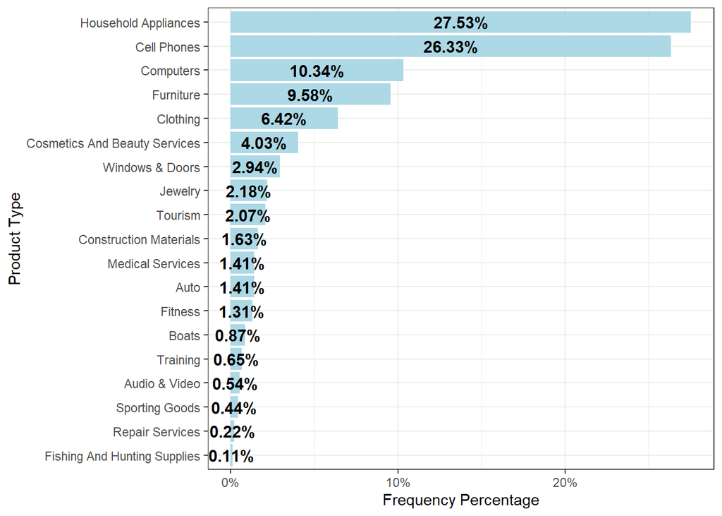

```r
### plot single discrete variable
### create plot
product_type_plot <- ggplot(
  ## data
  data = clients_work,
  ## mapping
  mapping = aes(
    # y-axis: variable of interest
    y =
      # reverse order
      fct_rev(
        # order by frequency of levels
        fct_infreq(product_type)
      ),
    # treat data as single group
    group = 1
  )
) +
  ## choose geometry with proportion calculation
  geom_bar(
    ## mapping
    mapping = aes(
      # x-axis: proportions
      x = after_stat(prop)
    ),
    # fill
    fill = "lightblue"
  ) +
  ## text geometry
  geom_text(
    # stat
    stat = "count",
    # add label
    aes(
      # x-axis: proportions
      x = after_stat(prop),
      # label and number of digits
      label = percent(
        # label
        after_stat(prop)
      )
    ),
    # justify horizontally above bar
    color = "black",
    # size of text
    size = 4,
    # font
    fontface = "bold",
    # position label in middle of bars
    position = position_stack(
      # middle of bar
      vjust = 0.5
    )
  ) +
  ## change format of x-axis
  scale_x_continuous(
    # percents
    labels = percent_format()
  ) +
  ## label axes
  labs(
    # x-axis
    x = "Frequency Percentage",
    # y-axis
    y = "Product Type"
  ) +
  ## theme
  theme_bw()

## show plot
product_type_plot
```

## Task 5.2

Create a histogram plot of **credit_term**. First, bind the name **credit_term_hist_plot** to a **ggplot()** object. Second, inside of **ggplot()** specify **clients_work** as the *data* input; map **credit_term** to the *x-axis*. Third, add a **geom_histogram()** layer; set **bins** to **8**; set **fill** to **red**. Fourth, add a **stat_bin()** layer; set **geom** to **“text”**; map **count** to the **label** using **after_stat()**; map **group** to **1**; set **bins** to **8**; set **color** to **black**; set **size** to **5**; set **position** to **position_stack()** with **vjust** set to **0.5**. Fifth, alter the x-axis with **scale_x_continuous()** setting **n.breaks** to **8**. Sixth, set the axes labels with **labs()**; set the *x-axis* to **“Credit Term”**; set the *y-axis* to **“Count”**.

Show the plot.

**Question 5.2**: Answer these questions: (1) Are there more clients with a *credit term* of approximately *30-35* or *35-40*? (2) Are there more than *300* individuals with a *credit term* of approximately *12.5-17*?

**Response 5.2**: (1) 35-40 (2) Yes

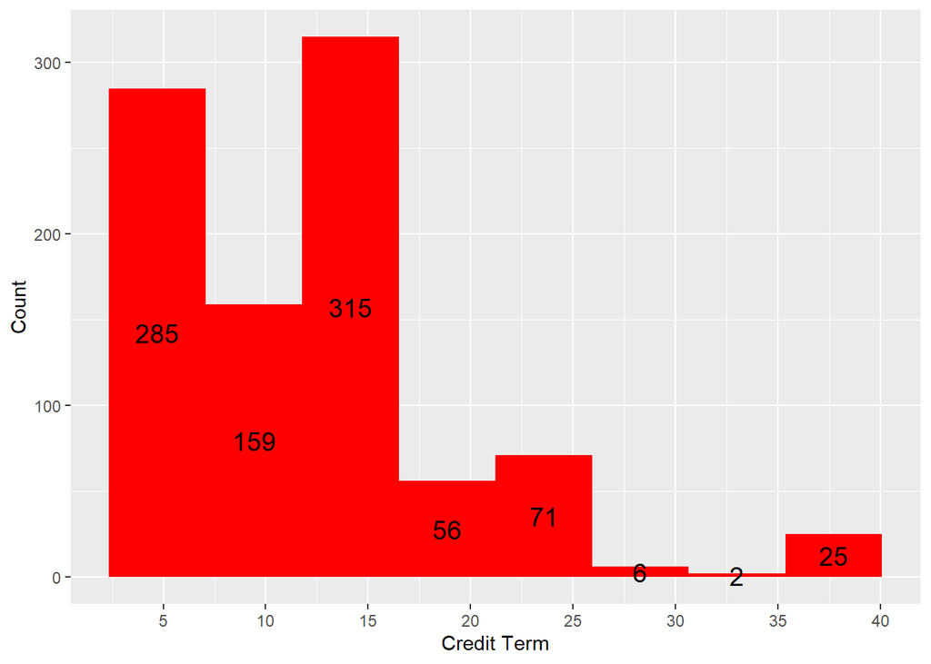

```r
### histogram of single continuous variable
## choose data and mapping
credit_term_hist_plot <- ggplot(
  ## data
  data = clients_work,
  ## mapping
  mapping = aes(
    # x-axis
    x = credit_term
  )
) +
  ## choose geometry with proportion calculation
  geom_histogram(
    # number of bins
    bins = 8,
    # fill
    fill = "red"
  ) +
  ## text geometry above bars
  stat_bin(
    ## geometry
    geom = "text",
    # add label
    aes(
      # label and number of digits
      label = after_stat(count),
      # treat data as single group
      group = 1
    ),
    # number of bins
    bins = 8,
    # justify horizontally above bar
    color = "black",
    # size of text
    size = 5,
    # position label in middle of bars
    position = position_stack(
      # middle of bar
      vjust = 0.5
    )
  ) +
  ## adjust x-axis scale
  scale_x_continuous(
    # number of breaks
    n.breaks = 8
  ) +
  ## label axes
  labs(
    # x-axis
    x = "Credit Term",
    # y-axis
    y = "Count"
  )

## show plot
credit_term_hist_plot
```

## Task 5.3

Create a density plot of **credit_term**. First, bind the name **credit_term_density_plot** to a **ggplot()** object. Second, inside of **ggplot()** specify **clients_work** as the *data* input; map **credit_term** to the *x-axis*. Third, set the axes labels with **labs()**; set the *x-axis* to **“Credit Term”**; set the *y-axis* to **“Density”**. Fourth, set the title with **ggtitle()**; set the main title to **“Skewed Distribution of Credit Term”**; set the subtitle to **“Client Data for Second 6 Months”**. Fifth, set the theme to **theme_dark()**.

Show the plot.

**Question 5.3**: How many modes (i.e., peaks) do you see for *credit terms* falling between *0* to *20* months?

**Response 5.3**: 3

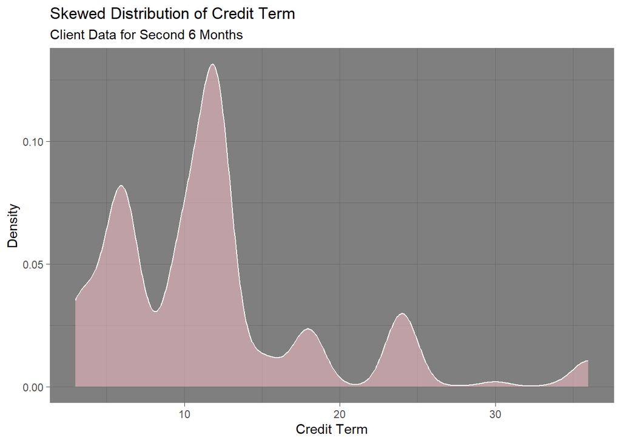

```r
### density plot of single continuous variable
## choose data and mapping
credit_term_density_plot <- ggplot(
  ## data
  data = clients_work,
  ## mapping
  mapping = aes(
    # x-axis
    x = credit_term
  )
) +
  ## choose geometry with proportion calculation
  geom_density(
    # fill
    fill = "pink",
    # color
    color = "white",
    # transparency
    alpha = 0.5
  ) +
  ## label axes
  labs(
    # x-axis
    x = "Credit Term",
    # y-axis
    y = "Density"
  ) +
  ## title
  ggtitle(
    # main title
    "Skewed Distribution of Credit Term",
    # subtitle
    subtitle = "Client Data for Second 6 Months"
  ) +
  ## theme
  theme_dark()

## show plot
credit_term_density_plot
```

## Task 5.4

Create a bar plot calculating the *percentage* of *men* and *women* from various *regions*. First, bind the name **region_gender_plot** to a **ggplot()** object. Second, inside of **ggplot()** specify **clients_work** as the *data* input; map **region** to the *x-axis*; map **sex** to the **group** and **fill** aesthetics. Third, add a **geom_bar()** layer; map **prop** to the *y-axis* using **after_stat()**; set **position** to **“dodge”**. Fourth, set the axes labels with **labs()**; set the *x-axis* to **“Region”**. set the *y-axis* to **“Frequency Percentage by Gender”**; set the **fill** to **“Gender”**. Fifth, alter the y-axis with **scale_y_continuous()** setting **labels** to **percent_format()**. Sixth, add a **geom_text()** layer; set **stat** to **“count”**; map **prop** to the *y-axis* using **after_stat()**; map **prop** to the **label** using **after_stat()** and **percent()**; set **vjust** to **-0.5**; set **position** to **position_dodge()** with **width** set to **0.9**; set **size** to **3**. Seventh, set **palette** to **“Set1”** in **scale_fill_brewer()**. Eighth, set the main title to **“Small Differences in Region by Gender”**.

Show the plot.

**Question 5.4**: Are men and women similarly distributed across the regions?

**Response 5.4**: The amount of men to women are similar across all regions, however, the west has perdominatly more men and women than the east and midwest.

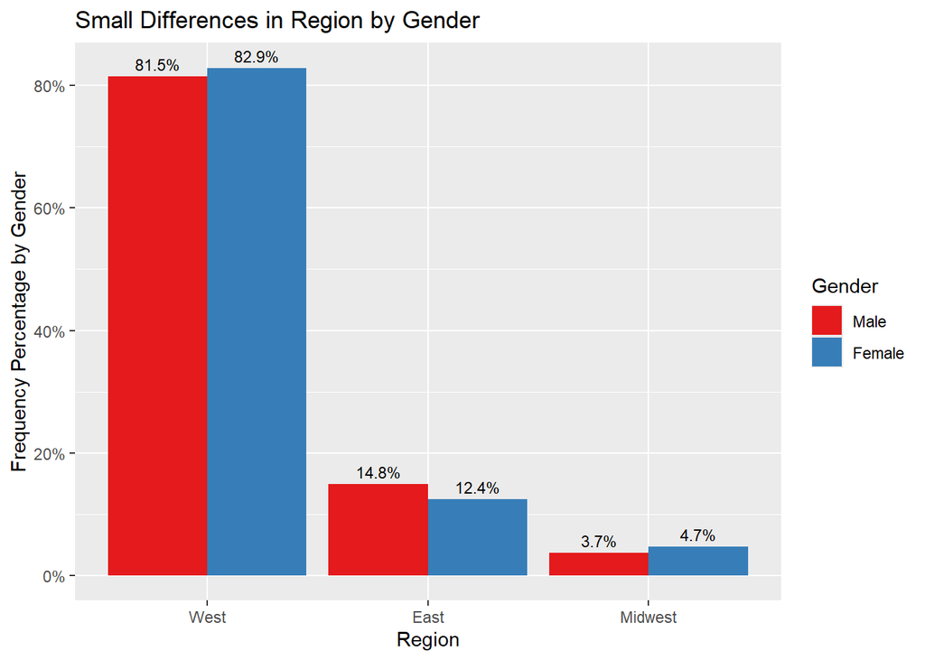

```r
### plot multiple categorical variables;
### plot percentage of men and women in each role
### relative to own gender
## save plot
region_gender_plot <- ggplot(
  ## data
  data = clients_work,
  ## specify mapping
  mapping = aes(
    # x-axis
    x = region,
    # groups
    group = sex,
    # fill
    fill = sex
  )
) +
  ## choose geometry with proportion calculation
  geom_bar(
    ## mapping
    aes(
      # y-axis: proportion
      y = after_stat(prop)
    ),
    ## place bars side-by-side
    position = "dodge"
  ) +
  ## label mappings
  labs(
    # x-axis
    x = "Region",
    # y-axis
    y = "Frequency Percentage by Gender",
    # legend
    fill = "Gender"
  ) +
  ## change format of y-axis
  scale_y_continuous(
    # percents
    labels = percent_format()
  ) +
  ## add text to bars
  geom_text(
    # stat for geometry
    stat = "count",
    # aesthetics
    aes(
      # proportion
      y = after_stat(prop),
      # label and number of digits
      label = percent(
        # labels
        after_stat(prop),
        # decimals
        accuracy = 0.1
      )
    ),
    # justify vertically above bar
    vjust = -0.5,
    # position label above each bar
    position = position_dodge(
      # width
      width = 0.9
    ),
    # size of text
    size = 3
  ) +
  ## scale color
  scale_fill_brewer(
    # palette
    palette = "Set1"
  ) +
  ## add descriptive title
  ggtitle("Small Differences in Region by Gender")

# Display the plot
region_gender_plot
```

## Task 5.5

Create a scatter plot *credit term* and *credit amount*. First, bind the name **credit_term_amount_plot** to a **ggplot()** object. Second, inside of **ggplot()** specify **clients_work** as the *data* input; map **credit_term** to the *x-axis*; map **credit_amount** to the **y-axis**. Third, add a **geom_point()** layer; set **alpha** to **0.4**; set **color** to **“blue”**. Fourth, add a **geom_smooth()** layer; set **method** to **“loess”**; set **formula** to **“y ~ x”**; set **se** to **FALSE**; set **color** to **“red”**. Fifth, alter the y-axis with **scale_y_continuous()** setting **labels** to **dollar_format()**. Sixth, set the axes labels with **labs()**; set the *x-axis* to **“Credit Term”**. set the *y-axis* to **“Credit Amount”**.

Show the plot.

**Question 5.5**: Does the relationship between *credit amount* and *credit term* trend *positively* or *negatively*?

**Response 5.5**: The relationship trends positively.

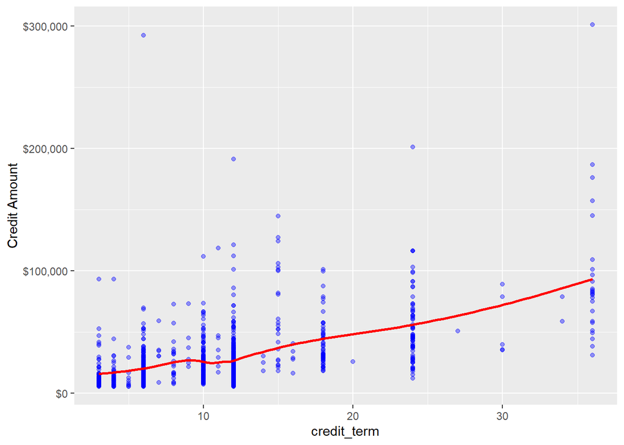

```r
### examine relationship between two numeric variables;
### use loess line to examine type of relationship
## save plot
credit_term_amount_plot <- ggplot(
  ## data
  clients_work,
  ## mapping
  aes(
    # x-axis
    x = credit_term,
    # y-axis
    y = credit_amount
  )
) +
  ## choose point geometry for scatterplot
  geom_point(
    # transparency
    alpha = 0.4,
    # color
    color = "blue"
  ) +
  ## loess line
  geom_smooth(
    # smoother
    method = "loess",
    # formula
    formula = "y ~ x",
    # standard error ribbon
    se = FALSE,
    # color
    color = "red"
  ) +
  ## scale y-axis
  scale_y_continuous(
    # dollars
    labels = dollar_format()
  ) +
  ## label axes
  labs(
    # x-axis
    x = "credit_term",
    # y-axis
    y = "Credit Amount"
  )

## show plot
credit_term_amount_plot
```

## Task 5.6

Create a box plot of *income* as a function of *family status*. First, bind the name **income_fam_stat_plot** to a **ggplot()** object. Second, inside of **ggplot()** specify **clients_work** as the *data* input; map **family_status** to the *x-axis*; map **income** to the **y-axis**; map **family_status** to the **fill**. Third, add a **geom_boxplot()** layer; set **outlier.color** to **“red”**; set **outlier.size** to **2**. Fourth, add a **geom_jitter()** layer; set **width** to **0.01**; set **alpha** to **0.2**. Fifth, set the axes labels with **labs()**; set the *x-axis* to **“Credit Term”**. set the *y-axis* to **“Income”**. Sixth, set **palette** to **“Set1”** in **scale_fill_brewer()**. Seventh, remove the legend in **theme()** by setting **legend.position** to **“none”**.

Show the plot.

**Question 5.6**: Which category of *family status* has the largest outliers?

**Response 5.6**: Unmarried

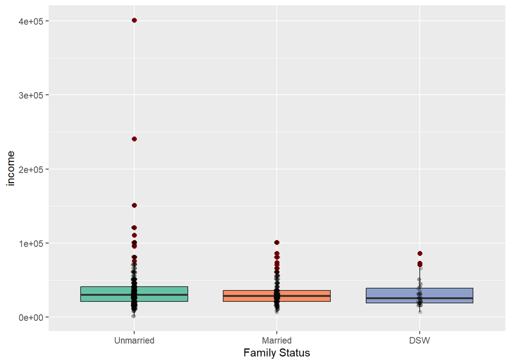

```r
### create boxplot
## save plot
income_fam_stat_plot <- ggplot(
  ## data
  clients_work,
  ## mapping
  aes(
    # x-axis
    x = family_status,
    # y-axis
    y = income,
    # fill
    fill = family_status
  )
) +
  ## add boxplot
  geom_boxplot(
    # color of outliers
    outlier.color = "darkred",
    # size of outliers
    outlier.size = 2
  ) +
  ## add points
  geom_jitter(
    # amount to jitter
    width = 0.01,
    # transparency
    alpha = 0.2
  ) +
  ## labels
  labs(
    # x-axis
    x = "Family Status",
    # y-axis
    y = "income"
  ) +
  ## scale color
  scale_fill_brewer(
    # palette
    palette = "Set2"
  ) +
  ## update theme
  theme(
    # remove legend
    legend.position = "none"
  )

## show plot
income_fam_stat_plot
```

# Task 6: Save Objects

For this task, you will save the objects you created.

First, save the working data, **clients_work**, as the data file: **clients_s2_work.csv** in the **data** folder of the project directory using **write_excel_csv()** and **here()**.

Second, save the six plots from the fifth task as **png** files in the **plots** folder of the project directory using the combination of **walk()**, **ls()**, **ggsave()**, **here()**, **str_glue()**, **str_remove()**, and **get()**. Use a width of *8.1 inches* and a height of *5 inches*.

```r
### save working data
## use write_excel_csv() to export as a csv data file
write_excel_csv(
  ## name of object
  clients_work,
  ## use here() to export data to project directory;
  here("data", "clients_s2_work.csv")
)

### save plots
## call function
walk(
  ## vector of plots
  ls(
    # name pattern
    pattern = "plot"
  ),
  ## function
  function(plot_inp) {
    ### save plot
    ## call function
    ggsave(
      ## file path
      here(
        # folder
        "plots",
        # file
        str_glue(
          # remove string
          str_remove(
            # string
            plot_inp,
            # pattern
            "_plot"
          ),
          # extension
          ".png"
        )
      ),
      ## plot object
      plot = get(plot_inp),
      ## units
      units = "in",
      ## width
      width = 8.1,
      ## height
      height = 5
    )
  }
)
```

# Task 7: Conceptual Questions

For your last task, you will respond to conceptual questions based on the conceptual lectures for this week.

**Question 7.1**: What is a percentile of a variable?

**Response 7.1**: A percentile of a variable is a measure that indicates the relative standing of a particular value within the entire dataset. It represents the percentage of data points that are less than or equal to a given value. For example, the 75th percentile of a dataset is the value below which 75% of the data falls.

**Question 7.2**: What is the difference between the variance and standard deviation of a variable?

**Response 7.2**: Variance is the average of the squared differences between each data point and the mean. It is calculated as the sum of squared differences divided by the number of data points.Standard deviation, on the other hand, is the square root of the variance. It is expressed in the same units as the original data and provides a more interpretable measure of spread than variance.

**Question 7.3**: What five statistics are computed in a box plot?

**Response 7.3**: Minimum: The smallest value in the dataset. First quartile (Q1): The value below which 25% of the data falls. Median (Q2): The middle value of the dataset when it is ordered from smallest to largest. Third quartile (Q3): The value below which 75% of the data falls. Maximum: The largest value in the dataset.